# Cardio Good Fitness Project

## Background

Cardio Good Fitness is a sporting goods store that does a good number of sales in treadmills. Currently it wants to increase the sales of it’s treadmills and wants to use big data to drive actionable insights and beneficial results

## Objective

To extract actionable insights from the data that we have collected of the various customers to increase sales and identify areas of growth and improvement. We will be majorly focusing on these areas Customer profile (characteristics of a customer) of the different products Variables that influence sales Insights and recommendations that will help the company in targeting new customers

## Key Questions:

What are the different variables that influence sales?  
Which factor affects the sales the most? What could be plausible reasons for that?  
What are your recommendations to Cardio Good Fitness management?

## Data Description

1. Product - The model no. of the treadmill
2. Age - Age of the customer in no of years
3. Gender - Gender of the customer
4. Education - Education of the customer in no. of years
5. Marital Status - Marital status of the customer
6. Usage - Avg. # times the customer wants to use the treadmill every week
7. Fitness - Self rated fitness score of the customer (5 - very fit, 1 - very unfit)
8. Income - Income of the customer
9. Miles- Miles that a customer expects to run

## Importation of necessary libraries

```python
# Library to suppress warnings or deprecation notes
import warnings
warnings.filterwarnings('ignore')
```

```python
# Libraries to help with reading and manipulating data
import pandas as pd
import numpy as np
import matplotlib.pyplot as plt

# Libraries to help with data visualization
import seaborn as sns
import matplotlib.pyplot as plt
%matplotlib inline
```

## Loading and Viewing of Dataset

```python
book=pd.read_csv('CardioGoodFitness.csv')
```

```python
# copying data to another varaible to avoid any changes to original data
bc = book.copy()
```

```python
# looking at head (5 observations)
bc.head()
```

|  | Product | Age | Gender | Education | MaritalStatus | Usage | Fitness | Income | Miles |
| --- | --- | --- | --- | --- | --- | --- | --- | --- | --- |
| 0 | TM195 | 18 | Male | 14 | Single | 3 | 4 | 29562 | 112 |
| 1 | TM195 | 19 | Male | 15 | Single | 2 | 3 | 31836 | 75 |
| 2 | TM195 | 19 | Female | 14 | Partnered | 4 | 3 | 30699 | 66 |
| 3 | TM195 | 19 | Male | 12 | Single | 3 | 3 | 32973 | 85 |
| 4 | TM195 | 20 | Male | 13 | Partnered | 4 | 2 | 35247 | 47 |

```python
bc.shape
```

```
(180, 9)
```

The dataset has 180 rows and 9 columns

```python
bc.info()
```

```
<class 'pandas.core.frame.DataFrame'>
RangeIndex: 180 entries, 0 to 179
Data columns (total 9 columns):
 #   Column         Non-Null Count  Dtype
---  ------         --------------  -----
 0   Product        180 non-null    object
 1   Age            180 non-null    int64
 2   Gender         180 non-null    object
 3   Education      180 non-null    int64
 4   MaritalStatus  180 non-null    object
 5   Usage          180 non-null    int64
 6   Fitness        180 non-null    int64
 7   Income         180 non-null    int64
 8   Miles          180 non-null    int64
dtypes: int64(6), object(3)
memory usage: 12.8+ KB
```

#### Observations

All columns have 180 rows  
Product, Gender, MaritalStatus and Fitness should be categorical variables

## Data Preprocessing

### Fixing of Datatypes

```python
#Product column should be converted to categorical type
#Gender column should be converted to categorical type
#MaritalStatus column should be converted to categorical type

bc['Product']=bc.Product.astype('category')
bc['Gender']=bc.Gender.astype('category')
bc['MaritalStatus']=bc.MaritalStatus.astype('category')
bc['Fitness']=bc.Fitness.astype('category')
bc['Education']=bc.Education.astype('category')
```

```python
bc.info()
```

```
<class 'pandas.core.frame.DataFrame'>
RangeIndex: 180 entries, 0 to 179
Data columns (total 9 columns):
 #   Column         Non-Null Count  Dtype
---  ------         --------------  -----
 0   Product        180 non-null    category
 1   Age            180 non-null    int64
 2   Gender         180 non-null    category
 3   Education      180 non-null    category
 4   MaritalStatus  180 non-null    category
 5   Usage          180 non-null    int64
 6   Fitness        180 non-null    category
 7   Income         180 non-null    int64
 8   Miles          180 non-null    int64
dtypes: category(5), int64(4)
memory usage: 7.6 KB
```

### Summary of the Data

```python
bc.describe().T
```

|  | count | mean | std | min | 25% | 50% | 75% | max |
| --- | --- | --- | --- | --- | --- | --- | --- | --- |
| Age | 180.0 | 28.788889 | 6.943498 | 18.0 | 24.00 | 26.0 | 33.00 | 50.0 |
| Usage | 180.0 | 3.455556 | 1.084797 | 2.0 | 3.00 | 3.0 | 4.00 | 7.0 |
| Income | 180.0 | 53719.577778 | 16506.684226 | 29562.0 | 44058.75 | 50596.5 | 58668.00 | 104581.0 |
| Miles | 180.0 | 103.194444 | 51.863605 | 21.0 | 66.00 | 94.0 | 114.75 | 360.0 |

There is a large difference between the 3rd quartile and the max value for Income and Miles. As such there could be outliers to the right of these variables

The Income has a wide range indicating that people with various types of jobs purchase treadmills

Miles also has a wide range indicating that there are various levels of fitness. This will be useful when using the various Fitness level categories

```python
bc.describe(exclude='number').T
```

|  | count | unique | top | freq |
| --- | --- | --- | --- | --- |
| Product | 180 | 3 | TM195 | 80 |
| Gender | 180 | 2 | Male | 104 |
| Education | 180 | 8 | 16 | 85 |
| MaritalStatus | 180 | 2 | Partnered | 107 |
| Fitness | 180 | 5 | 3 | 97 |

#### Observations

Variable 'Product' has 3 unique categories

```python
#Making a list of all catrgorical variables
cat_col=['Product', 'Gender','MaritalStatus','Fitness','Education']

#Printing number of count of each unique value in each column
for column in cat_col:
    print(df[column].value_counts())
    print('-'*50)
```

```
TM195    80
TM498    60
TM798    40
Name: Product, dtype: int64
--------------------------------------------------
Male      104
Female     76
Name: Gender, dtype: int64
--------------------------------------------------
Partnered    107
Single        73
Name: MaritalStatus, dtype: int64
--------------------------------------------------
3    97
5    31
2    26
4    24
1     2
Name: Fitness, dtype: int64
--------------------------------------------------
16    85
14    55
18    23
13     5
15     5
12     3
21     3
20     1
Name: Education, dtype: int64
--------------------------------------------------
```

#### Observations

There are more Males than Females  
There are more Partnered buyers than Single indicating that two are sharing  
Most members have rated their fitness at 3 (average) which correlates with the Usage

### Missing Values Check

```python
# checking missing values
bc.isna().sum()
```

```
Product          0
Age              0
Gender           0
Education        0
MaritalStatus    0
Usage            0
Fitness          0
Income           0
Miles            0
dtype: int64
```

There are no missing values in the data

# EDA

## Numerical Variables

```python
# function to plot a boxplot and a histogram along the same scale.

def histogram_boxplot(data, feature, figsize=(12, 7), kde=False, bins=None):
    f2, (ax_box2, ax_hist2) = plt.subplots(
        nrows=2,  # Number of rows of the subplot grid= 2
        sharex=True,  # x-axis will be shared among all subplots
        gridspec_kw={"height_ratios": (0.25, 0.75)},
        figsize=figsize,
    )  # creating the 2 subplots
    sns.boxplot(
        data=data, x=feature, ax=ax_box2, showmeans=True, color="violet"
    )  # boxplot will be created and a star will indicate the mean value of the column
    sns.histplot(
        data=data, x=feature, kde=kde, ax=ax_hist2, bins=bins, palette="winter"
    ) if bins else sns.histplot(
        data=data, x=feature, kde=kde, ax=ax_hist2
    )  # For histogram
    ax_hist2.axvline(
        data[feature].mean(), color="green", linestyle="--"
    )  # Add mean to the histogram
    ax_hist2.axvline(
        data[feature].median(), color="black", linestyle="-"
    )  # Add median to the histogram
```

### Observations on Age

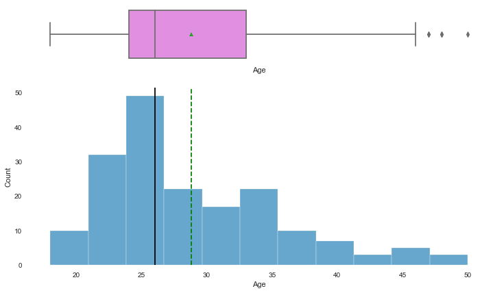

```python
histogram_boxplot(bc, 'Age')
```

#### Observation

The distriution of Age is rightly skewed  
Most of the buyers are between 25 and 30  
Mean is ~29 while median is ~26  
There are a few outliers on the right

### Observations on Income

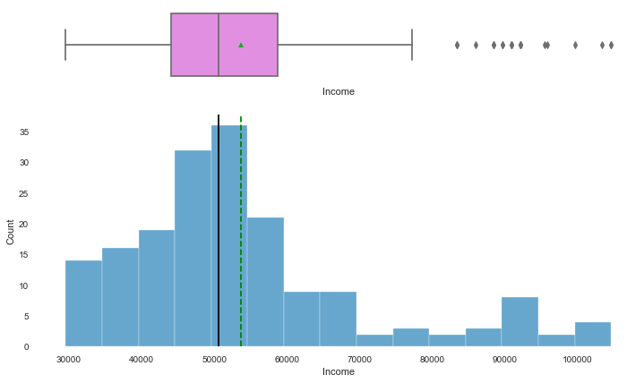

```python
histogram_boxplot(bc, 'Income')
```

#### Observation

Both the median and Mean income are closely related  
However there are some outliers on the right  
Most buyers seem to earn around the 50,000 mark

### Observations on Miles

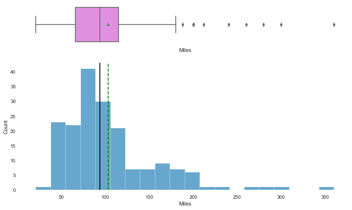

```python
histogram_boxplot(bc, 'Miles')
```

### Observations on Usage

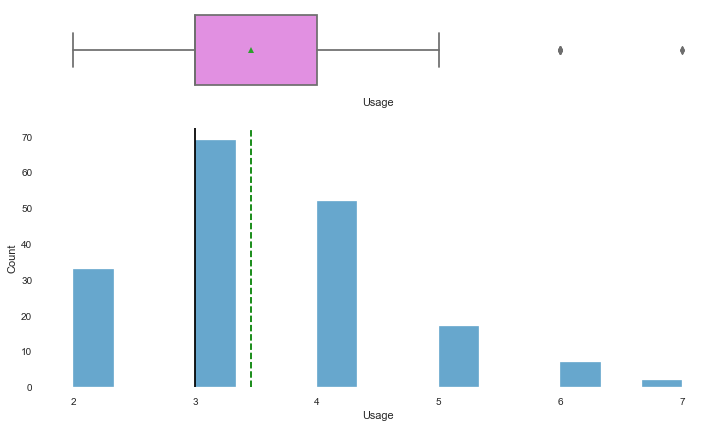

```python
histogram_boxplot(bc, 'Usage')
```

## Categorical Variables

```python
# function to create labeled barplots


def labeled_barplot(data, feature, perc=False, n=None):
    """
    Barplot with percentage at the top

    data: dataframe
    feature: dataframe column
    perc: whether to display percentages instead of count (default is False)
    n: displays the top n category levels (default is None, i.e., display all levels)
    """

    total = len(data[feature])  # length of the column
    count = data[feature].nunique()
    if n is None:
        plt.figure(figsize=(count + 1, 5))
    else:
        plt.figure(figsize=(n + 1, 5))

    plt.xticks(rotation=90, fontsize=15)
    ax = sns.countplot(
        data=data,
        x=feature,
        palette="Paired",
        order=data[feature].value_counts().index[:n].sort_values(),
    )

    for p in ax.patches:
        if perc == True:
            label = "{:.1f}%".format(
                100 * p.get_height() / total
            )  # percentage of each class of the category
        else:
            label = p.get_height()  # count of each level of the category

        x = p.get_x() + p.get_width() / 2  # width of the plot
        y = p.get_height()  # height of the plot

        ax.annotate(
            label,
            (x, y),
            ha="center",
            va="center",
            size=12,
            xytext=(0, 5),
            textcoords="offset points",
        )  # annotate the percentage

    plt.show()  # show the plot
```

### Observations on Product

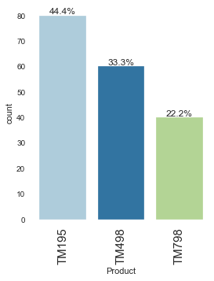

```python
plt.figure(figsize=(10,7))
labeled_barplot(bc, 'Product', perc=True)
```

#### Observations

TM195 is the most commonly bought product.  
The reason why could be important for recommendations

### Observations on Gender

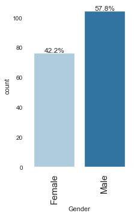

```python
plt.figure(figsize=(10,7))
labeled_barplot(bc, 'Gender', perc=True)
```

#### Observations

There are more male than female buyers of the treadmills

### Observations on Marital Status

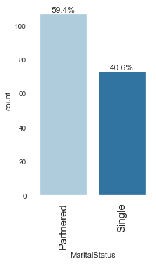

```python
plt.figure(figsize=(10,7))
labeled_barplot(bc, 'MaritalStatus', perc=True)
```

#### Observations

There are more partnered than single buyers

### Observations on Fitness

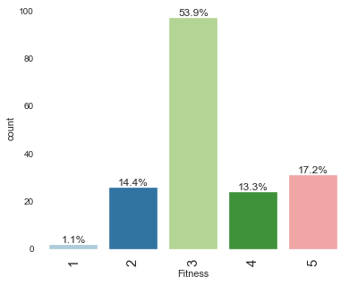

```python
plt.figure(figsize=(10,7))
labeled_barplot(bc, 'Fitness', perc=True)
```

#### Observations

Fitness level 3 is has the highest number of observations by a wide margin  
The rest of the levels except Level 1 have a reasonably uniform distribution of observations

# Bivariate Analysis

## Correlation

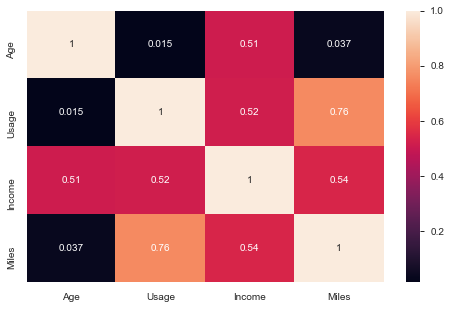

```python
plt.figure(figsize=(8, 5))
sns.heatmap(bc.corr(),annot=True)
plt.show()
```

#### Observations

As expected, Age and Usage do not have a strong correlation  
Age and Income have a reasonably strong correlation which is fine  
There is a strong correlation with Usage and Miles as expected  
Usage and Income have a reasonably strong correlation which is fine  
It is important to note that correlation does not imply causation

## Bivariate Scatter Plots

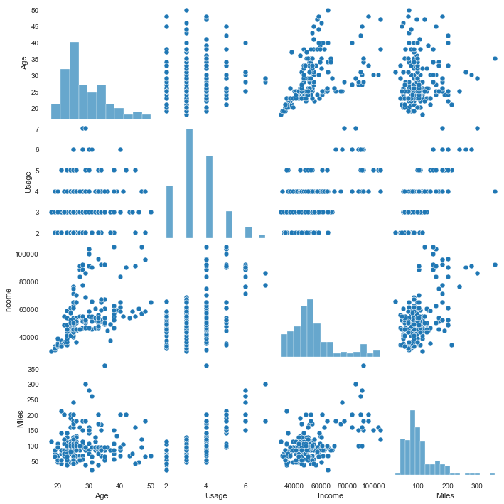

```python
sns.pairplot(bc)
plt.show()
```

#### Observations

We get the same insights from the correlation plot

## Multivariate Analysis

### Check for various trends across the Products

#### Income across the Products

```python
# getting the mean of the income across the products
bcgi = bc.groupby(by=['Product'])['Income'].mean()
```

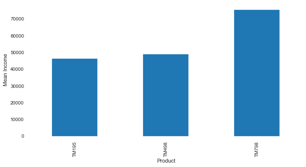

```python
bcgi.plot(kind='bar',ylabel='Mean Income',xlabel='Product',figsize=(10,5))
```

#### Observation

Buyers with the highest mean income purchase the TM798

#### Age across the Products

```python
# getting the mean of the Age across the products
bcga = bc.groupby(by=['Product'])['Age'].mean()
```

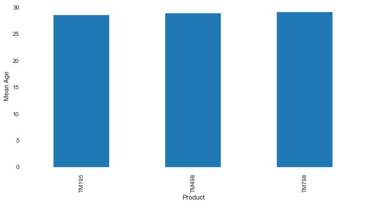

```python
bcga.plot(kind='bar',ylabel='Mean Age',xlabel='Product',figsize=(10,5))
```

#### Observation

The mean age is the same across all three products, indicating no real preference due to age

#### Usage Level across the Products

```python
# getting the mean of Usage level across the products
bcgu = bc.groupby(by=['Product'])['Usage'].mean()
```

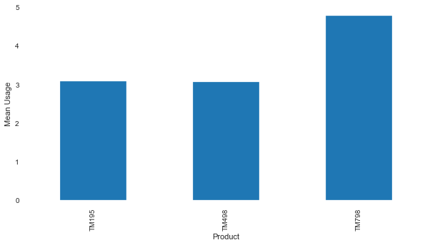

```python
bcgu.plot(kind='bar',ylabel='Mean Usage',xlabel='Product',figsize=(10,5))
```

#### Observation

The TM798 has the highest mean usage of the 3 products

#### Miles Run across the Products

```python
# getting the mean of Miles run across the products
bcgm = bc.groupby(by=['Product'])['Miles'].mean()
```

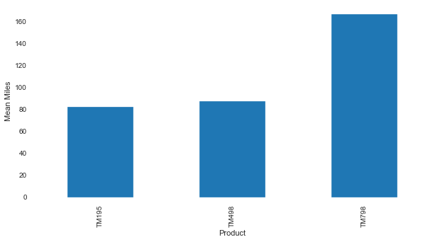

```python
bcgm.plot(kind='bar',ylabel='Mean Miles',xlabel='Product',figsize=(10,5))
```

#### Observation

The TM798 has the highest number of Miles used. This correlates with the above data showing the high usage

```python
# getting the mean of the income across the products and marital status
bcgpm = bc.groupby(by=['Product','MaritalStatus'])['Income'].mean()
print(bcgpm)
```

```
Product  MaritalStatus
TM195    Partnered        47848.750000
         Single           44271.937500
TM498    Partnered        49522.666667
         Single           48150.125000
TM798    Partnered        82047.173913
         Single           66504.588235
Name: Income, dtype: float64
```

```python
# getting the mean of the income across the products and gender
bcgpg = bc.groupby(by=['Product','Gender'])['Income'].mean()
print(bcgpg)
```

```
Product  Gender
TM195    Female    46020.075000
         Male      46815.975000
TM498    Female    49336.448276
         Male      48634.258065
TM798    Female    73633.857143
         Male      75825.030303
Name: Income, dtype: float64
```

# Profile by Treadmill

### TM195

1. Has the highest number of buyers
2. Average income of 46,418
3. Average usage of 3.1 times a week
4. Average fitness level of 3
5. Average miles run of 82.8

### TM498

1. Has the second highest number of buyers
2. Average income of 48,974
3. Average usage of 3.1 times a week
4. Average fitness level of 2.9
5. Average miles run of 87.9

### TM798

1. Has the lowest highest number of buyers
2. Partnered buyers earn more than single buyers
3. Average income of 75,442
4. Average usage of 4.8 times a week
5. Average fitness level of 4.6
6. Average miles run of 166.9

# Conclusion and Recommendations

## Conclusion

I analysed the 180 buyers of the Cardio Good Fitness. The main features of interest here are Usage, Income and Product. From a purely business perspective, having products that aren't being used is just increasing cost. Thus, I determined the factors that affect Usage and the nature of their effect.

## Recommendations to business

1. TM195 is the most common product. However, TM798 is the most used product. As such more should be made available to the buyers that desire the product
2. There are more partnered buyers. As such, there should be pricing offers targeted at partners
3. TM798 seems to be the product for the 'serious' buyers. As such, the product should be heavily featured in campaigns
4. Campaigns to women should be made available as there are currently more male than female buyers
5. We need to procure more data on price and build a model that can predict optimal pricing

```python
! jupyter nbconvert --to html Project_Week1.ipynb
```

```
[NbConvertApp] Converting notebook Project_Week1.ipynb to html
[NbConvertApp] Writing 881570 bytes to Project_Week1.html
```

```python
from pandas_profiling import ProfileReport
# Use the original dataframe, so that original features are considered
prof = ProfileReport(book)
# to view report created by pandas profile
prof
```

[interactive chart not shown]

```python
prof.to_file(output_file='Project_Module1.html')
```